# Practical Machine Learning Course Project

Michael Normyle

December 6, 2017

```r
#load libraries
library(caret)
library(e1071)
```

```r
#load train and test data
#for train data, deleted all predictors with missing & NA
train <- read.csv("pml-training3.csv")
test <- read.csv("pml-testing.csv")
#fit model with gbm given wide variety of predictors
#figure they will work as weak learners
#fitting model with all predictors without missing/NA data
modFit <- train(classe ~., method="gbm", data=train,
                na.action=na.omit)
#fit model to test data
pred <-predict(modFit, test)
#print prediction
pred
```

```
##  [1] B A B A A E D B A A B C B A E E A B B B
## Levels: A B C D E
```

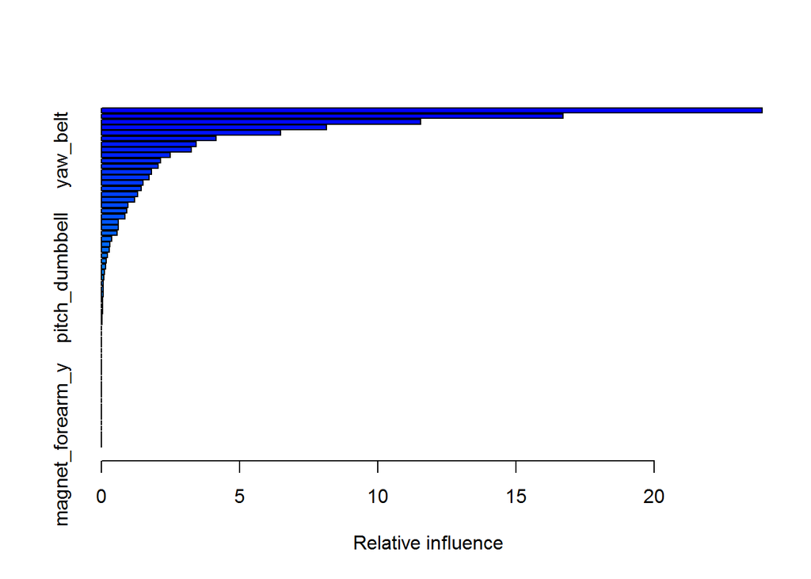

```
##                                       var     rel.inf
## raw_timestamp_part_1 raw_timestamp_part_1 23.90226983
## roll_belt                       roll_belt 16.69149713
## num_window                     num_window 11.54404212
## pitch_forearm               pitch_forearm  8.14625707
## magnet_dumbbell_z       magnet_dumbbell_z  6.48933905
## magnet_dumbbell_y       magnet_dumbbell_y  4.15671735
## roll_forearm                 roll_forearm  3.42498232
## yaw_belt                         yaw_belt  3.25851101
## magnet_belt_z               magnet_belt_z  2.49899608
## roll_dumbbell               roll_dumbbell  2.13675438
## pitch_belt                     pitch_belt  2.05955046
## accel_forearm_x           accel_forearm_x  1.81852809
## gyros_dumbbell_y         gyros_dumbbell_y  1.71848876
## gyros_belt_z                 gyros_belt_z  1.51141725
## accel_dumbbell_z         accel_dumbbell_z  1.43460823
## accel_dumbbell_y         accel_dumbbell_y  1.32160026
## accel_belt_z                 accel_belt_z  1.21275915
## accel_dumbbell_x         accel_dumbbell_x  0.95865737
## roll_arm                         roll_arm  0.91133115
## yaw_arm                           yaw_arm  0.86156713
## gyros_belt_y                 gyros_belt_y  0.60968779
## magnet_arm_x                 magnet_arm_x  0.60845527
## magnet_dumbbell_x       magnet_dumbbell_x  0.57989520
## magnet_belt_y               magnet_belt_y  0.38263753
## gyros_arm_y                   gyros_arm_y  0.30496062
## magnet_forearm_z         magnet_forearm_z  0.29044357
## magnet_arm_z                 magnet_arm_z  0.22104561
## magnet_arm_y                 magnet_arm_y  0.17283833
## accel_forearm_y           accel_forearm_y  0.15376913
## accel_forearm_z           accel_forearm_z  0.12084329
## pitch_dumbbell             pitch_dumbbell  0.08956240
## user_namecharles         user_namecharles  0.07050402
## total_accel_dumbbell total_accel_dumbbell  0.06627412
## yaw_forearm                   yaw_forearm  0.06235213
## magnet_belt_x               magnet_belt_x  0.05111005
## gyros_dumbbell_z         gyros_dumbbell_z  0.04858154
## gyros_forearm_z           gyros_forearm_z  0.04595585
## gyros_belt_x                 gyros_belt_x  0.03323774
## gyros_dumbbell_x         gyros_dumbbell_x  0.02997162
## user_namecarlitos       user_namecarlitos  0.00000000
## user_nameeurico           user_nameeurico  0.00000000
## user_namejeremy           user_namejeremy  0.00000000
## user_namepedro             user_namepedro  0.00000000
## raw_timestamp_part_2 raw_timestamp_part_2  0.00000000
## new_windowyes               new_windowyes  0.00000000
## total_accel_belt         total_accel_belt  0.00000000
## accel_belt_x                 accel_belt_x  0.00000000
## accel_belt_y                 accel_belt_y  0.00000000
## pitch_arm                       pitch_arm  0.00000000
## total_accel_arm           total_accel_arm  0.00000000
## gyros_arm_x                   gyros_arm_x  0.00000000
## gyros_arm_z                   gyros_arm_z  0.00000000
## accel_arm_x                   accel_arm_x  0.00000000
## accel_arm_y                   accel_arm_y  0.00000000
## accel_arm_z                   accel_arm_z  0.00000000
## yaw_dumbbell                 yaw_dumbbell  0.00000000
## total_accel_forearm   total_accel_forearm  0.00000000
## gyros_forearm_x           gyros_forearm_x  0.00000000
## gyros_forearm_y           gyros_forearm_y  0.00000000
## magnet_forearm_x         magnet_forearm_x  0.00000000
## magnet_forearm_y         magnet_forearm_y  0.00000000
```

```r
#see predictor influence
summary(modFit)
```

## R Markdown

I started the model building process by looking at the training data. I saw that there were many variables with missing and NA values. The training data has 158 different series (including the classe series), but 100 of them have missing and NA values, so I eliminated those series.

Then, since there are still many predictors, some of which seem like they could be of varying importance, I thought the boosting (gbm) model would be a good option. This is because the boosting algorithm requires the predictors to be little better than a random guess to be of use.

As far as cross validation is concerned, I had better success using the default settings for gbm, inasmuch as I did not use any specific setting for trainControl. When I tried using bootstrapping with 10 resamples, it caused issues with R summarizing the model. So the posted R code excludes this.

I then ran the model on the test set and got the predicted values. I did not expect the out of sample error to be significant since there was such a wide breadth and depth of data available.

Then, in running the 20 predicted values through the Course Project Prediction Quiz, the model was 100% accurate.